# nfe vs wecare: glm QQ-plots

started: Alexey Larionov, 25Mar2017  
last updated: Alexey Larionov, 01Apr2017

# Summary

Make QQ plot(s) for nfe vs wecare to see whether there is an inflation (recommended by DC during the Skype meeting of 14Mar2017)

Use genes with > 2 variants in wecare-nfe 23,523 -> 17,482 variants 10,159 -> 5,324 genes

Aggregate per gene by summarising selected inverted weighted variants

Make QQ-plot by using simple logit regression on the aggregated data - add 3 top eigenvectors to the model

Todo: add an option for calculations w/o weighting (uniform weight = 1)

# start_section

```r
# Start time
Sys.time()
```

```
## [1] "2017-04-01 19:17:44 BST"
```

```r
# Folders
#/analysis/mtgroup_share
#/scratch /medgen
setwd("/analysis/mtgroup_share/scripts/wecare_stat_03.17/scripts")
source_data_folder <- "/analysis/mtgroup_share/scripts/wecare_stat_03.17/source_data"
interim_data_folder <- "/analysis/mtgroup_share/scripts/wecare_stat_03.17/interim_data"
results_folder <- "/analysis/mtgroup_share/scripts/wecare_stat_03.17/results"
```

# load_data

```r
# Load data
load(paste(interim_data_folder, "s07_filter_by_variant_effect_Mar2017.RData", sep="/"))
```

# check_data

```r
dim(wecare_nfe_genotypes.mx)
```

```
## [1] 23523   676
```

```r
class(wecare_nfe_genotypes.mx)
```

```
## [1] "matrix"
```

```r
wecare_nfe_genotypes.mx[1:5,1:5]
```

```
##              HG00097 HG00099 HG00100 HG00102 HG00106
## Var000000026       0       0       0       0       0
## Var000000029       0       0       0       0       0
## Var000000031       0       0       0       0       0
## Var000000053       0       0       0       0       0
## Var000000064      NA       0       0       0       0
```

```r
dim(wecare_nfe_genes.df)
```

```
## [1] 10159     2
```

```r
class(wecare_nfe_genes.df)
```

```
## [1] "data.frame"
```

```r
wecare_nfe_genes.df[1:5,]
```

```
##         genes counts_per_gene
## NOC2L   NOC2L               4
## KLHL17 KLHL17               3
## AGRN     AGRN             147
## TTLL10 TTLL10               2
## ACAP3   ACAP3               2
```

```r
dim(wecare_nfe_kgen.df)
```

```
## [1] 23523     9
```

```r
colnames(wecare_nfe_kgen.df)
```

```
## [1] "SplitVarID"  "kgen.AC"     "kgen.AN"     "kgen.AF"     "kgen.AFR_AF"
## [6] "kgen.AMR_AF" "kgen.EAS_AF" "kgen.EUR_AF" "kgen.SAS_AF"
```

```r
wecare_nfe_kgen.df[1:5,1:5]
```

```
##                SplitVarID kgen.AC kgen.AN     kgen.AF kgen.AFR_AF
## Var000000026 Var000000026      NA      NA          NA          NA
## Var000000029 Var000000029       1    5008 0.000199681           0
## Var000000031 Var000000031       1    5008 0.000199681           0
## Var000000053 Var000000053      NA      NA          NA          NA
## Var000000064 Var000000064      NA      NA          NA          NA
```

```r
dim(wecare_nfe_exac.df)
```

```
## [1] 23523    48
```

```r
colnames(wecare_nfe_exac.df)
```

```
##  [1] "SplitVarID"              "exac_non_TCGA.AF"
##  [3] "exac_non_TCGA.AC"        "exac_non_TCGA.AN"
##  [5] "exac_non_TCGA.AC_FEMALE" "exac_non_TCGA.AN_FEMALE"
##  [7] "exac_non_TCGA.AC_MALE"   "exac_non_TCGA.AN_MALE"
##  [9] "exac_non_TCGA.AC_Adj"    "exac_non_TCGA.AN_Adj"
## [11] "exac_non_TCGA.AC_Hom"    "exac_non_TCGA.AC_Het"
## [13] "exac_non_TCGA.AC_Hemi"   "exac_non_TCGA.AC_AFR"
## [15] "exac_non_TCGA.AN_AFR"    "exac_non_TCGA.Hom_AFR"
## [17] "exac_non_TCGA.Het_AFR"   "exac_non_TCGA.Hemi_AFR"
## [19] "exac_non_TCGA.AC_AMR"    "exac_non_TCGA.AN_AMR"
## [21] "exac_non_TCGA.Hom_AMR"   "exac_non_TCGA.Het_AMR"
## [23] "exac_non_TCGA.Hemi_AMR"  "exac_non_TCGA.AC_EAS"
## [25] "exac_non_TCGA.AN_EAS"    "exac_non_TCGA.Hom_EAS"
## [27] "exac_non_TCGA.Het_EAS"   "exac_non_TCGA.Hemi_EAS"
## [29] "exac_non_TCGA.AC_FIN"    "exac_non_TCGA.AN_FIN"
## [31] "exac_non_TCGA.Hom_FIN"   "exac_non_TCGA.Het_FIN"
## [33] "exac_non_TCGA.Hemi_FIN"  "exac_non_TCGA.AC_NFE"
## [35] "exac_non_TCGA.AN_NFE"    "exac_non_TCGA.Hom_NFE"
## [37] "exac_non_TCGA.Het_NFE"   "exac_non_TCGA.Hemi_NFE"
## [39] "exac_non_TCGA.AC_SAS"    "exac_non_TCGA.AN_SAS"
## [41] "exac_non_TCGA.Hom_SAS"   "exac_non_TCGA.Het_SAS"
## [43] "exac_non_TCGA.Hemi_SAS"  "exac_non_TCGA.AC_OTH"
## [45] "exac_non_TCGA.AN_OTH"    "exac_non_TCGA.Hom_OTH"
## [47] "exac_non_TCGA.Het_OTH"   "exac_non_TCGA.Hemi_OTH"
```

```r
wecare_nfe_exac.df[1:5,1:5]
```

```
##                SplitVarID exac_non_TCGA.AF exac_non_TCGA.AC
## Var000000026 Var000000026               NA               NA
## Var000000029 Var000000029        1.506e-04               16
## Var000000031 Var000000031        2.354e-04               25
## Var000000053 Var000000053        1.883e-05                2
## Var000000064 Var000000064        9.416e-06                1
##              exac_non_TCGA.AN exac_non_TCGA.AC_FEMALE
## Var000000026               NA                      NA
## Var000000029           106210                       8
## Var000000031           106210                       4
## Var000000053           106210                       0
## Var000000064           106206                       0
```

```r
dim(wecare_nfe_variants.df)
```

```
## [1] 23523    50
```

```r
str(wecare_nfe_variants.df)
```

```
## 'data.frame':    23523 obs. of  50 variables:
##  $ SplitVarID        : Factor w/ 343824 levels "Var000000001",..: 26 29 31 53 64 65 167 191 227 237 ...
##  $ SYMBOL            : Factor w/ 19862 levels "A1BG","A1CF",..: 11149 11149 11149 8665 8665 8665 540 540 540 540 ...
##  $ TYPE              : Factor w/ 2 levels "INDEL","SNP": 2 2 2 2 2 2 2 2 2 2 ...
##  $ CHROM             : Factor w/ 25 levels "1","10","11",..: 1 1 1 1 1 1 1 1 1 1 ...
##  $ POS               : int  881871 883883 883946 897287 897792 897802 979748 982844 987173 989899 ...
##  $ REF               : Factor w/ 2142 levels "A","AAAAAAAAAAAAAAAAAAAAAAAG",..: 1044 1575 539 539 539 1575 1 1044 1575 539 ...
##  $ ALT               : Factor w/ 1297 levels "A","AAAAAAAAAAAAACT",..: 1 323 989 989 989 664 989 323 664 989 ...
##  $ ac_raw            : int  1 2 1 1 1 1 53 106 1 1 ...
##  $ af_raw            : num  0.000711 0.001555 0.000774 0.000711 0.000722 ...
##  $ an_raw            : int  1406 1286 1292 1406 1386 1390 1416 1388 1420 1414 ...
##  $ Consequence       : Factor w/ 78 levels "3_prime_UTR_variant",..: 66 28 28 28 66 28 28 24 28 28 ...
##  $ SIFT_call         : Factor w/ 4 levels "deleterious",..: NA 1 1 1 NA 1 1 NA 1 1 ...
##  $ SIFT_score        : num  NA 0 0.01 0.04 NA 0 0.01 NA 0 0.02 ...
##  $ PolyPhen_call     : Factor w/ 4 levels "benign","possibly_damaging",..: NA 3 3 3 NA 3 3 NA 3 3 ...
```

[output cut: 36 more lines]

```r
wecare_nfe_variants.df[1:5,1:5]
```

```
##                SplitVarID SYMBOL TYPE CHROM    POS
## Var000000026 Var000000026  NOC2L  SNP     1 881871
## Var000000029 Var000000029  NOC2L  SNP     1 883883
## Var000000031 Var000000031  NOC2L  SNP     1 883946
## Var000000053 Var000000053 KLHL17  SNP     1 897287
## Var000000064 Var000000064 KLHL17  SNP     1 897792
```

```r
dim(wecare_nfe_phenotypes.df)
```

```
## [1] 676  38
```

```r
str(wecare_nfe_phenotypes.df)
```

```
## 'data.frame':    676 obs. of  38 variables:
##  $ wes_id        : chr  "HG00097" "HG00099" "HG00100" "HG00102" ...
##  $ gwas_id       : chr  NA NA NA NA ...
##  $ merged_id     : chr  NA NA NA NA ...
##  $ filter        : chr  "pass" "pass" "pass" "pass" ...
##  $ cc            : num  -1 -1 -1 -1 -1 -1 -1 -1 -1 -1 ...
##  $ setno         : int  NA NA NA NA NA NA NA NA NA NA ...
##  $ registry      : chr  NA NA NA NA ...
##  $ family_history: int  NA NA NA NA NA NA NA NA NA NA ...
##  $ age_dx        : int  NA NA NA NA NA NA NA NA NA NA ...
##  $ age_ref       : num  NA NA NA NA NA NA NA NA NA NA ...
##  $ rstime        : num  NA NA NA NA NA NA NA NA NA NA ...
##  $ eig1_gwas     : num  NA NA NA NA NA NA NA NA NA NA ...
##  $ eig2_gwas     : num  NA NA NA NA NA NA NA NA NA NA ...
##  $ eig3_gwas     : num  NA NA NA NA NA NA NA NA NA NA ...
```

[output cut: 24 more lines]

```r
wecare_nfe_phenotypes.df[1:5,1:5]
```

```
##          wes_id gwas_id merged_id filter cc
## HG00097 HG00097    <NA>      <NA>   pass -1
## HG00099 HG00099    <NA>      <NA>   pass -1
## HG00100 HG00100    <NA>      <NA>   pass -1
## HG00102 HG00102    <NA>      <NA>   pass -1
## HG00106 HG00106    <NA>      <NA>   pass -1
```

```r
# Check consistency of rownames and colnames
sum(colnames(wecare_nfe_genotypes.mx) != rownames(wecare_nfe_phenotypes.df))
```

```
## [1] 0
```

```r
sum(rownames(wecare_nfe_genotypes.mx) != rownames(wecare_nfe_kgen.df))
```

```
## [1] 0
```

```r
sum(rownames(wecare_nfe_genotypes.mx) != rownames(wecare_nfe_exac.df))
```

```
## [1] 0
```

```r
sum(rownames(wecare_nfe_genotypes.mx) != rownames(wecare_nfe_variants.df))
```

```
## [1] 0
```

# select_variants

Should I use common - or at least present - in both?

Use genes with > 2 variants in wecare-nfe 23,523 -> 17,482 variants 10,159 -> 5,324 genes

```r
# --- Select variants for genes with > 2 aggregated events per dataset --- #

sel_genes <- wecare_nfe_genes.df[wecare_nfe_genes.df$counts_per_gene >= 3,"genes"]
length(sel_genes) # 5,324
```

```
## [1] 5324
```

```r
sel_genes[1:5]
```

```
## [1] "NOC2L"  "KLHL17" "AGRN"   "CCNL2"  "ATAD3C"
```

```r
sel_vars <- wecare_nfe_variants.df[wecare_nfe_variants.df$SYMBOL %in% sel_genes, "SplitVarID"]
sel_vars <- as.character(as.vector(sel_vars))
length(sel_vars) # 17,842
```

```
## [1] 17482
```

```r
sel_vars[1:5]
```

```
## [1] "Var000000026" "Var000000029" "Var000000031" "Var000000053"
## [5] "Var000000064"
```

```r
genotypes_sel.mx <- wecare_nfe_genotypes.mx[sel_vars,]
variants_sel.df <- wecare_nfe_variants.df[sel_vars,]

dim(genotypes_sel.mx)
```

```
## [1] 17482   676
```

```r
dim(variants_sel.df)
```

```
## [1] 17482    50
```

# invert_genotypes

Invert genotypes for variants with total AF > 0.5

```r
# Prepare tables for output
variants_sel_inv.df <- cbind(variants_sel.df,
                     inverted=rep(FALSE,nrow(variants_sel.df)),
                     ac_inv=variants_sel.df$ac_all,
                     an_inv=variants_sel.df$an_all,
                     af_inv=variants_sel.df$af_all)

genotypes_sel_inv.mx <- genotypes_sel.mx

# For each variant
for(var in sel_vars){

  # If total AF > 0.5
  if(variants_sel_inv.df[var,"af_all"] > 0.5){

    # Flag variant
    TRUE -> variants_sel_inv.df[var, "inverted"]

    # Invert genotypes
    genotypes <- genotypes_sel_inv.mx[var,]
    genotypes_inv <- genotypes
    0 -> genotypes_inv[genotypes == 2]
    2 -> genotypes_inv[genotypes == 0]
    genotypes_inv -> genotypes_sel_inv.mx[var,]

    # Calculate inverted AFs
    ac_inv <- sum(genotypes_inv, na.rm=TRUE)
    an_inv <- 2*sum(!is.na(genotypes_inv))
    af_inv <- ac_inv/an_inv

    # Add inverted AFs to the variants data.frame
    variants_sel_inv.df[var, c("ac_inv", "an_inv", "af_inv")] <- c(ac_inv, an_inv, af_inv)

    # Clean-up
    rm(genotypes, genotypes_inv, ac_inv, an_inv, af_inv)

  }
}

# Number of invered variants
sum(variants_sel_inv.df$inverted) # 171
```

```
## [1] 171
```

```r
# Some effects of inversion
max(variants_sel_inv.df$af_all) # ~0.99
```

```
## [1] 0.9990958
```

```r
max(variants_sel_inv.df$af_inv) # 0.5
```

```
## [1] 0.5
```

```r
max(apply(genotypes_sel.mx,1,sum,na.rm=TRUE)) # 1,345
```

```
## [1] 1345
```

```r
max(apply(genotypes_sel_inv.mx,1,sum,na.rm=TRUE)) # 666
```

```
## [1] 666
```

```r
# clean-up
rm(var, genotypes_sel.mx, variants_sel.df)
```

# impute_missed_data

During the aggregation we ned to handle NA values.  
Ideally, we could do imputation based on the haplotypes, taking into account ethnisity etc.  
Practically this imputation would be a major time investment (likely un-justifyed becuse of the rarity of our variants).

## NA handling in SKAT

SKAT does not use the haplotype-based imputation.  
Instead SKAT allows to pick from 3 strategies to handle NAs  
(see impute.method in SKAT function help):

**bestguess**  
The most likely genotype under HW equilibrium.  
This is:  
*REF-REF* for ALT-AF < 1/3  
*REF-ALT* for ALT-AF 1/3 to 2/3  
*ALT-ALT* for ALT-AF >2/3  
For rare variants in our case this is mainly REF-REF  
(i.e. 0 in additive scoring).

**fixed**  
2*ALT-AF, in rare variants it is close to 0

**random**  
Random pick from binomial(2,p)

## NA handling in this script

I use method equivalent to the “fixed” approach in SKAT:  
substitute NA with duplicated allelic frequency.

In fact, this would be ~0 (very close to the “bestguess” for most variants)  
because of the low allelic frequencies. Considering the callrate > 90%,  
the imputation should not have major effect either.

```r
# Prepare matrix for output
genotypes_sel_inv_imp.mx <- genotypes_sel_inv.mx

# Fraction of missed data
sum(is.na(genotypes_sel_inv.mx))/(nrow(genotypes_sel_inv.mx)*ncol(genotypes_sel_inv.mx))
```

```
## [1] 0.07507511
```

```r
# Impute missed data
for(var in sel_vars){

    # Get AF (corrected for the inverted variants)
    af <- variants_sel_inv.df[var,"af_inv"]

    # Impute missed genotypes
    2*af -> genotypes_sel_inv_imp.mx[var, is.na(genotypes_sel_inv_imp.mx[var,])]

    # Clean-up
    rm(af)

}

sum(is.na(genotypes_sel_inv_imp.mx))
```

```
## [1] 0
```

```r
# Clean-up
rm(genotypes_sel_inv.mx, var)
```

# weight_variants

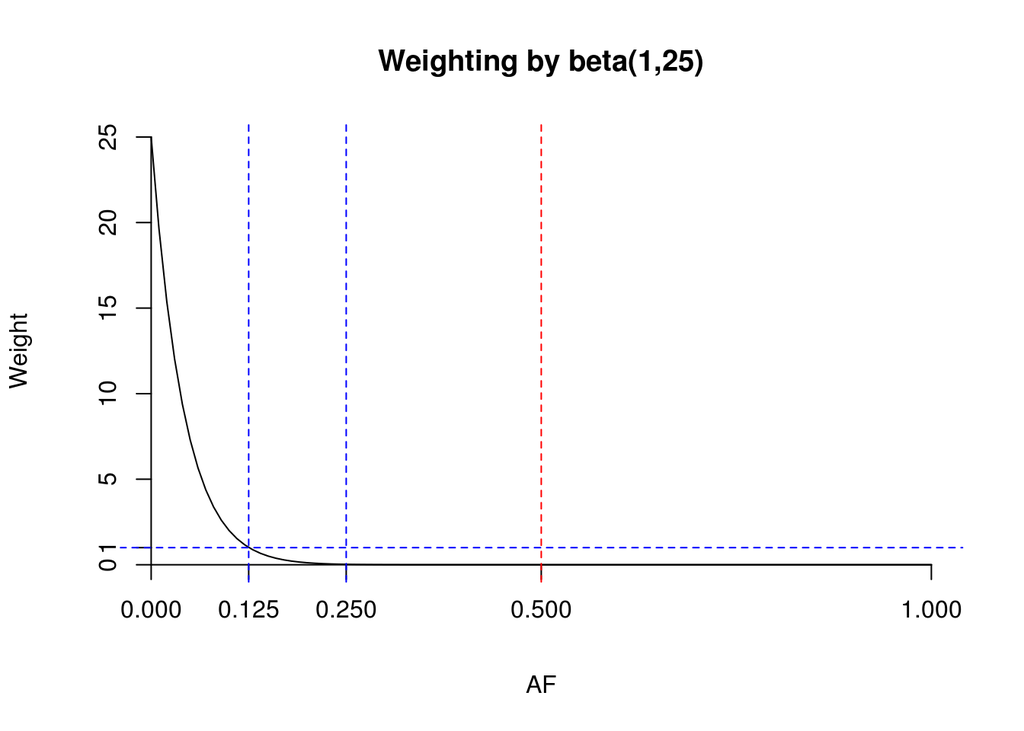

```r
# Explore beta(1,25) weights
x <- c(0:100)/100
y <- dbeta(x, 1, 25)
plot(x, y, type="l", lty=1, xlab="AF", ylab="Weight",
     xaxt="n", yaxt="n", bty='n', main = "Weighting by beta(1,25)")
axis(side=1, pos=0, at=c(0, 0.125, 0.25, 0.5, 1))
axis(side=2, pos=0, at=c(0, 5, 10, 15, 20, 25))
axis(side=2, pos=0, at=c(1)) # added separately to avoid hiding (too close to 0 to show)

abline(v=0.5, col="red", lty = 2)
abline(h=1, col="blue", lty = 2)
abline(v=0.125, col="blue", lty = 2)
abline(v=0.25, col="blue", lty = 2)
```

```r
dbeta(0, 1, 25) # 25
```

```
## [1] 25
```

```r
dbeta(0.125, 1, 25) # ~1
```

```
## [1] 1.014223
```

```r
dbeta(0.25, 1, 25) # ~0
```

```
## [1] 0.02508478
```

```r
dbeta(0.5, 1, 25) # 0
```

```
## [1] 1.490116e-06
```

```r
dbeta(1, 1, 25) # 0
```

```
## [1] 0
```

```r
rm(x,y)

# Prepare tables for output
variants_sel_inv_wt.df <- variants_sel_inv.df
variants_sel_inv_wt.df <- cbind(variants_sel_inv_wt.df, weight=1)

genotypes_sel_inv_imp_wt.mx <- genotypes_sel_inv_imp.mx

# Apply weighting
for(var in sel_vars){

  # Get AF (recalculated for inverted variants)
  af <- variants_sel_inv_wt.df[var, "af_inv"]

  # Calculate weight
  weight <- dbeta(af, 1, 25)

  # Write weight to variants table
  variants_sel_inv_wt.df[var,"weight"] <- weight

  # Apply weights to genotypes table
  genotypes_sel_inv_imp_wt.mx[var,] <- genotypes_sel_inv_imp_wt.mx[var,] * weight

  # Clean-up
  rm(af, weight)

}

# --- Explore effects of weighting --- #

# AFs
variants_sel_inv_wt.df$af_inv[6:12]
```

```
## [1] 0.0008561644 0.0381619938 0.0860215054 0.0007418398 0.0008051530
## [6] 0.0468253968 0.0008431703
```

```r
# Weights
round(variants_sel_inv_wt.df$weight[6:12],1)
```

```
## [1] 24.5  9.8  2.9 24.6 24.5  7.9 24.5
```

```r
# Genotypes
genotypes_sel_inv_imp.mx[6:12, 15:20]
```

```
##                  HG00128     HG00130     HG00132 HG00133 HG00137
## Var000000065 0.000000000 0.000000000 0.000000000       0       0
## Var000000167 0.000000000 0.000000000 0.000000000       0       1
## Var000000191 0.000000000 1.000000000 1.000000000       1       0
## Var000000227 0.000000000 0.000000000 0.000000000       0       0
## Var000000237 0.000000000 0.000000000 0.000000000       0       0
## Var000000503 0.000000000 1.000000000 0.000000000       0       0
## Var000000529 0.001686341 0.001686341 0.001686341       0       0
##                  HG00146
## Var000000065 0.001712329
## Var000000167 0.000000000
## Var000000191 0.000000000
## Var000000227 0.000000000
## Var000000237 0.000000000
## Var000000503 1.000000000
## Var000000529 0.000000000
```

```r
round(genotypes_sel_inv_imp_wt.mx[6:12, 15:20], 1)
```

```
##              HG00128 HG00130 HG00132 HG00133 HG00137 HG00146
## Var000000065       0     0.0     0.0     0.0     0.0     0.0
## Var000000167       0     0.0     0.0     0.0     9.8     0.0
## Var000000191       0     2.9     2.9     2.9     0.0     0.0
## Var000000227       0     0.0     0.0     0.0     0.0     0.0
## Var000000237       0     0.0     0.0     0.0     0.0     0.0
## Var000000503       0     7.9     0.0     0.0     0.0     7.9
## Var000000529       0     0.0     0.0     0.0     0.0     0.0
```

```r
# clean-up
rm(var, genotypes_sel_inv_imp.mx, variants_sel_inv.df)
```

# aggregate_variants_per_gene

Aggregate selected, inverted, imputed, weighted variants per gene.

```r
# Prepare table for the result
genes.mx <- matrix(nrow=0, ncol=ncol(genotypes_sel_inv_imp_wt.mx))
colnames(genes.mx) <- colnames(genotypes_sel_inv_imp_wt.mx)

# Aggregate (substitute NAs to 2*AF*Weight)
for(gene in sel_genes){

  #gene <- "ATM" # 16 vars
  #gene <- "CCNL2" # 1 var

  # Gene's variants
  vars <- as.vector(variants_sel_inv_wt.df[variants_sel_inv_wt.df$SYMBOL == gene, "SplitVarID"])

  # For a single variant per gene
  if(length(vars) == 1){

    # Get genotypes vector
    genotypes <- genotypes_sel_inv_imp_wt.mx[vars,]

    # Add to output matrix (no need in aggregation)
    aggregated_genotypes <- genotypes

    # Clean-up
    rm(genotypes)

  }else{ # for multiple variants per gene

    # Get genotypes matrix
    genotypes.mx <- genotypes_sel_inv_imp_wt.mx[vars,]

    # Aggregate
    aggregated_genotypes <- apply(genotypes.mx,2,sum)

    # Clean-up
    rm(genotypes.mx)
  }

  # Append
  genes.mx <- rbind(genes.mx, aggregated_genotypes)

  # Clean-up
  rm(aggregated_genotypes, vars)
}

# Add rownames
sel_genes -> rownames(genes.mx)

dim(genes.mx)
```

```
## [1] 5324  676
```

```r
# Clean-up
rm(gene, genotypes_sel_inv_imp_wt.mx, variants_sel_inv_wt.df, sel_vars)
```

# prepare_data_for_analysis

No missed data in eigenvectors, outcomes or genotypes

```r
# Eigenvectors
E_kgen50 <- as.matrix(wecare_nfe_phenotypes.df[,c("eig1_kgen50","eig2_kgen50","eig3_kgen50")])
E_nfe <- as.matrix(wecare_nfe_phenotypes.df[,c("eig1_nfe","eig2_nfe","eig3_nfe")])
E_kgen50[1:5,]
```

```
##         eig1_kgen50  eig2_kgen50  eig3_kgen50
## HG00097 0.017759087 -0.006751042 -0.005614329
## HG00099 0.007891847  0.005533403  0.007839381
## HG00100 0.012010045 -0.009068171  0.007279946
## HG00102 0.007413753 -0.001687041  0.020755489
## HG00106 0.008884354  0.006512593 -0.018333983
```

```r
E_nfe[1:5,]
```

```
##             eig1_nfe   eig2_nfe      eig3_nfe
## HG00097  0.001437968 0.06844403 -6.578024e-06
## HG00099 -0.011370220 0.07674417 -7.820950e-02
## HG00100 -0.013524331 0.03462285  8.796286e-03
## HG00102 -0.018763760 0.06141021  3.986292e-02
## HG00106  0.014829896 0.02356614  7.711363e-05
```

```r
sum(is.na(E_kgen50)) # 0
```

```
## [1] 0
```

```r
sum(is.na(E_nfe)) # 0
```

```
## [1] 0
```

```r
# Outcomes
Y <- ifelse(wecare_nfe_phenotypes.df$cc==-1, 0, 1)
sum(is.na(Y)) # 0
```

```
## [1] 0
```

```r
sum(Y) # 478
```

```
## [1] 478
```

```r
sum(!Y) # 198
```

```
## [1] 198
```

```r
# Genotypes: transpose
G <- t(genes.mx)
dim(G)
```

```
## [1]  676 5324
```

```r
G[1:5,1:5]
```

```
##         NOC2L     KLHL17       AGRN     CCNL2     ATAD3C
## HG00097     0 0.08062976 0.49663863 0.0000000 0.11901472
## HG00099     0 0.00000000 0.49663863 0.0000000 0.04131361
## HG00100     0 0.00000000 0.03948688 0.0000000 0.00000000
## HG00102     0 0.00000000 0.03948688 0.0000000 0.00000000
## HG00106     0 0.00000000 0.00000000 0.7406117 0.11901472
```

```r
sum(is.na(G)) # 0
```

```
## [1] 0
```

```r
# Clean-up
rm(genes.mx)
```

# logit_regression

Reccurent warnings:  
Warning: glm.fit: fitted probabilities numerically 0 or 1 occurred

```r
# Write header to output matrix
# (do not use data frame here: it will play with rbind!)
result.mx <- matrix(ncol=7, nrow=0)
colnames(result.mx) <- c("gene", "p_glm_kgen50", "p_anova_lrt_kgen50", "p_lrt_kgen50", "p_glm_nfe", "p_anova_lrt_nfe", "p_lrt_nfe")

# For each gene
for(gene in sel_genes){

  # Get vector of genotypes
  X <- G[,gene]

  # --- Calculate logit regression models with kgen50 eigenvectors --- #

  regE_kgen50 <- glm(Y ~ E_kgen50, family=binomial) # Null model
  regXE_kgen50 <- glm(Y ~ X + E_kgen50, family=binomial) # Complete model

  # Wald (?) test
  p_glm_kgen50 <- summary(regXE_kgen50)$coef["X", "Pr(>|z|)"]

  # Anova-LRT
  anova_lrt_kgen50 <- anova(regXE_kgen50, test="LRT")
  p_anova_lrt_kgen50 <- anova_lrt_kgen50["X", "Pr(>Chi)"]

  # LRT
  chi_stat_lrt_kgen50 = 2*(logLik(regXE_kgen50) - logLik(regE_kgen50))
  p_lrt_kgen50 = 1-pchisq(chi_stat_lrt_kgen50, df=1) # df??

  # Clean-up
  rm(regE_kgen50, regXE_kgen50, anova_lrt_kgen50, chi_stat_lrt_kgen50)

  # --- Calculate logit regression models with nfe eigenvectors --- #

  regE_nfe <- glm(Y ~ E_nfe, family=binomial) # Null model
  regXE_nfe <- glm(Y ~ X + E_nfe, family=binomial) # Complete model

  # Wald (?) test
  p_glm_nfe <- summary(regXE_nfe)$coef["X", "Pr(>|z|)"]

  # Anova-LRT
  anova_lrt_nfe <- anova(regXE_nfe, test="LRT")
  p_anova_lrt_nfe <- anova_lrt_nfe["X", "Pr(>Chi)"]

  # LRT
  chi_stat_lrt_nfe = 2*(logLik(regXE_nfe) - logLik(regE_nfe))
  p_lrt_nfe = 1-pchisq(chi_stat_lrt_nfe, df=1) # df??

  # Clean-up
  rm(regE_nfe, regXE_nfe, anova_lrt_nfe, chi_stat_lrt_nfe)

  # --- Record output to results table (p being converted to char) --- #
    result.mx <- rbind(result.mx, c(gene,
      p_glm_kgen50, p_anova_lrt_kgen50, p_lrt_kgen50, p_glm_nfe, p_anova_lrt_nfe, p_lrt_nfe))

  # Clean-up
  rm(X, p_glm_kgen50, p_anova_lrt_kgen50, p_lrt_kgen50, p_glm_nfe, p_anova_lrt_nfe, p_lrt_nfe)

} # next variant

# Clean-up
rm(G, Y, E_kgen50, E_nfe, gene, sel_genes)
```

# explore_result

```r
result.df <- as.data.frame(result.mx)

result.df$gene <- as.vector(result.df$gene)

result.df$p_glm_kgen50 <- as.numeric(as.vector(result.df$p_glm_kgen50))
result.df$p_anova_lrt_kgen50 <- as.numeric(as.vector(result.df$p_anova_lrt_kgen50))
result.df$p_lrt_kgen50 <- as.numeric(as.vector(result.df$p_lrt_kgen50))

result.df$p_glm_nfe <- as.numeric(as.vector(result.df$p_glm_nfe))
result.df$p_anova_lrt_nfe <- as.numeric(as.vector(result.df$p_anova_lrt_nfe))
result.df$p_lrt_nfe <- as.numeric(as.vector(result.df$p_lrt_nfe))

str(result.df)
```

```
## 'data.frame':    5324 obs. of  7 variables:
##  $ gene              : chr  "NOC2L" "KLHL17" "AGRN" "CCNL2" ...
##  $ p_glm_kgen50      : num  0.594 0.834 0.521 0.106 0.465 ...
##  $ p_anova_lrt_kgen50: num  0.234 0.903 0.984 0.278 0.29 ...
##  $ p_lrt_kgen50      : num  0.498 0.834 0.527 0.112 0.274 ...
##  $ p_glm_nfe         : num  0.692 0 0.985 0.644 0.882 ...
##  $ p_anova_lrt_nfe   : num  0.234 0.903 0.984 0.278 0.29 ...
##  $ p_lrt_nfe         : num  0.642 1 0.985 0.649 0.793 ...
```

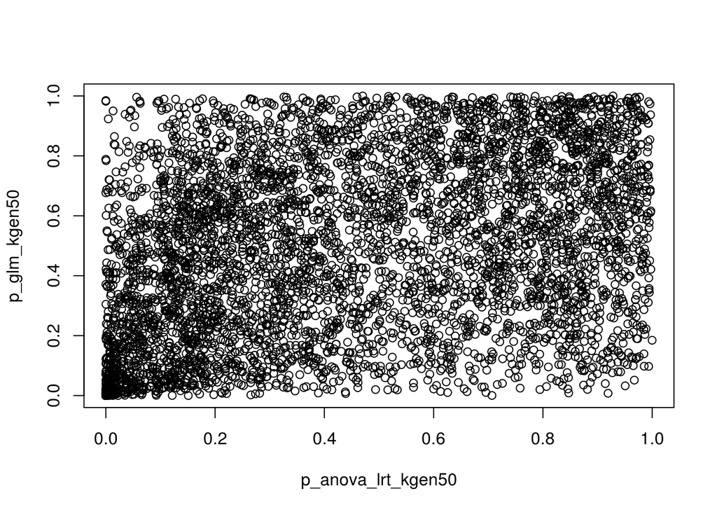

```r
# Sort result
result.df <- result.df[order(result.df$p_lrt_nfe),]

# Look at correlation of diferent p-estimates
# Anova does not correlate with anything
# glm(wald?) more or less correlate with lrt

plot(p_glm_kgen50~p_anova_lrt_kgen50, data=result.df)
```

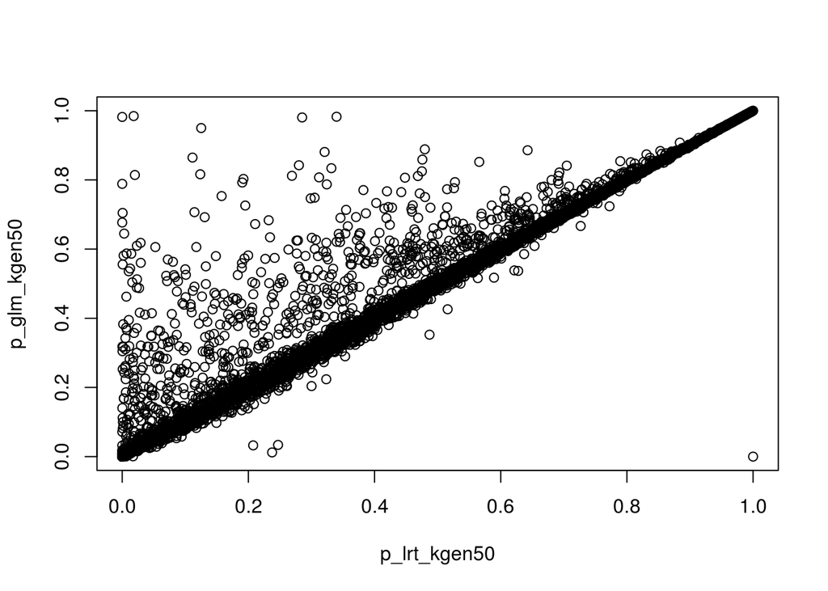

```r
plot(p_glm_kgen50~p_lrt_kgen50, data=result.df)
```

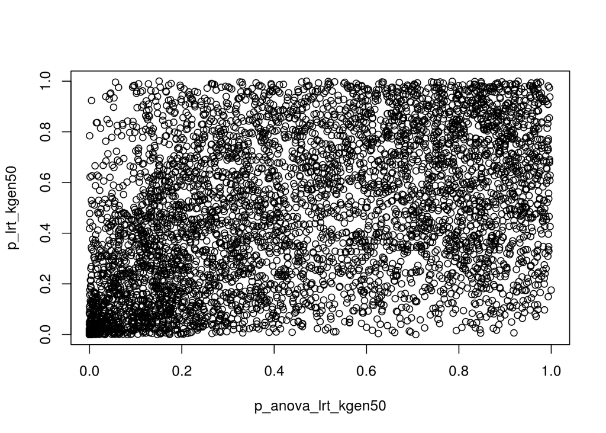

```r
plot(p_lrt_kgen50~p_anova_lrt_kgen50, data=result.df)
```

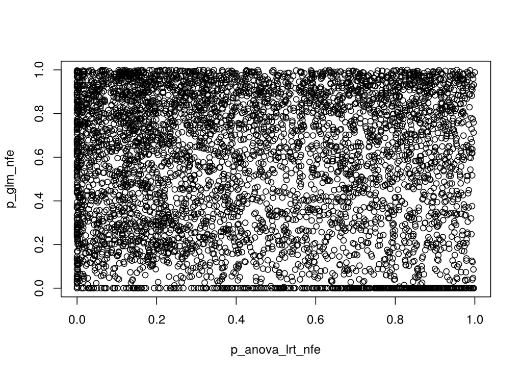

```r
plot(p_glm_nfe~p_anova_lrt_nfe, data=result.df)
```

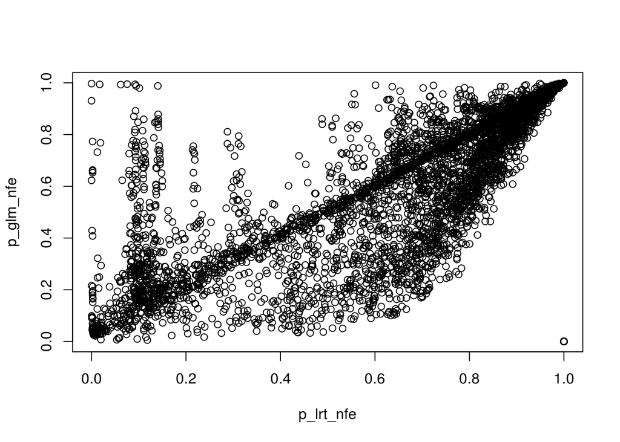

```r
plot(p_glm_nfe~p_lrt_nfe, data=result.df)
```

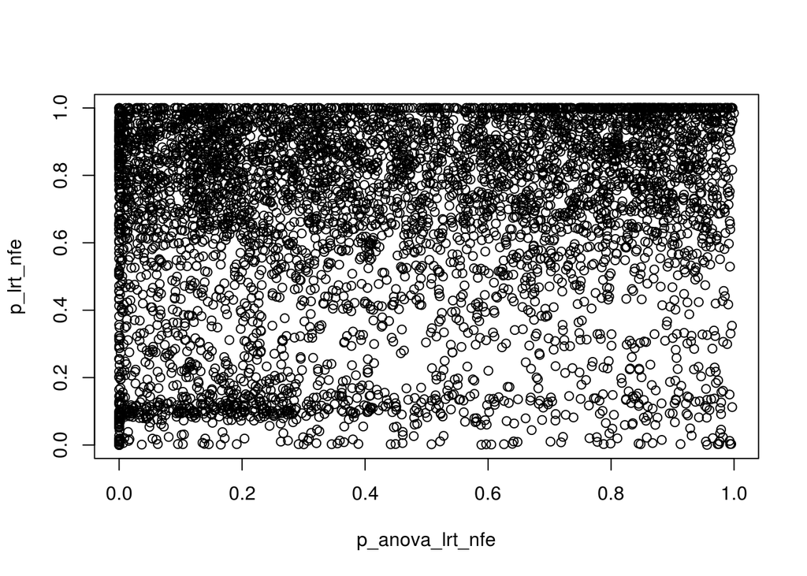

```r
plot(p_lrt_nfe~p_anova_lrt_nfe, data=result.df)
```

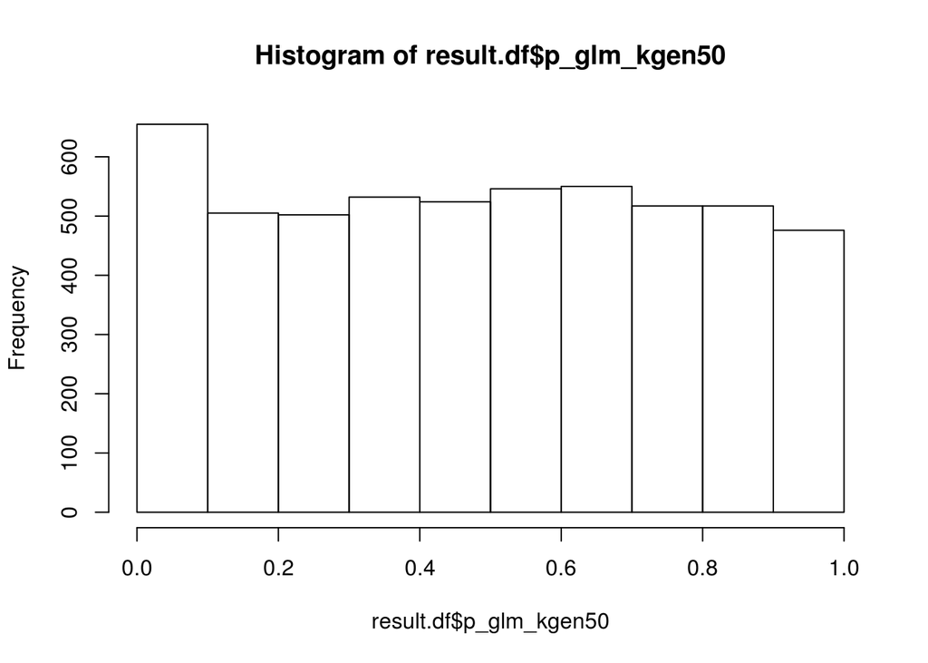

```r
# Look at histograms of p-values
hist(result.df$p_glm_kgen50)
```

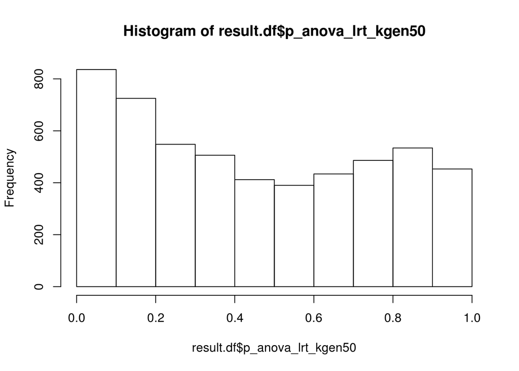

```r
hist(result.df$p_anova_lrt_kgen50)
```

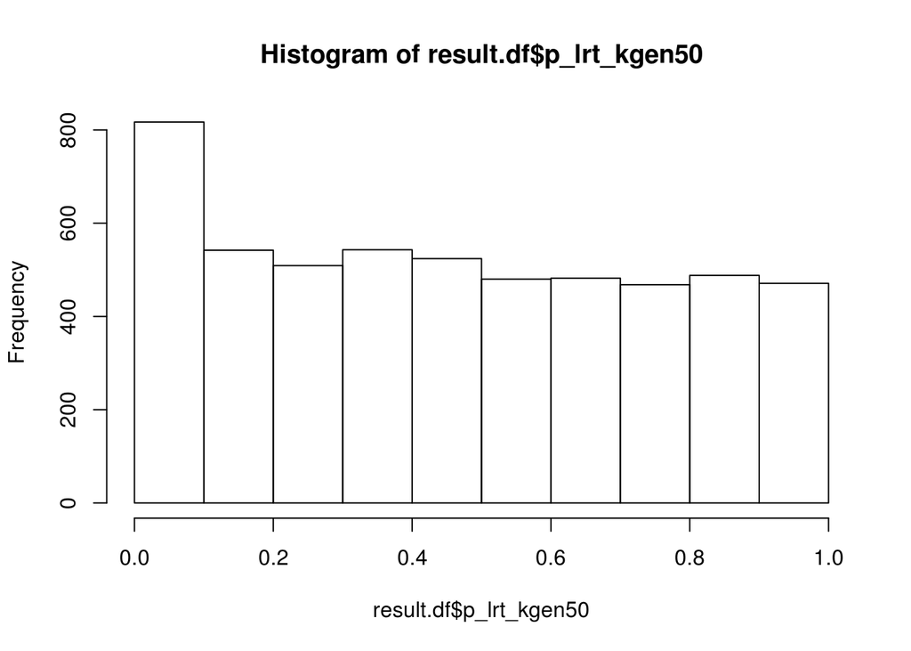

```r
hist(result.df$p_lrt_kgen50)
```

```r
sum(result.df$p_glm_kgen50 == 0)
```

```
## [1] 1
```

```r
sum(result.df$p_anova_lrt_kgen50 == 0)
```

```
## [1] 0
```

```r
sum(result.df$p_lrt_kgen50 == 0)
```

```
## [1] 48
```

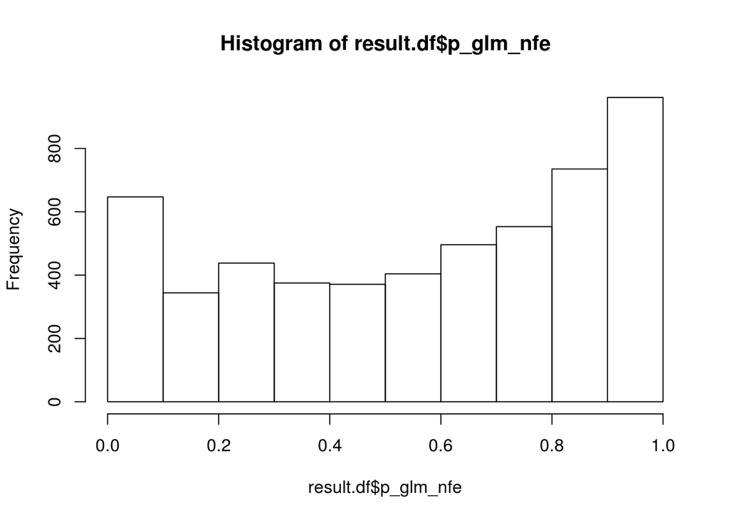

```r
hist(result.df$p_glm_nfe)
```

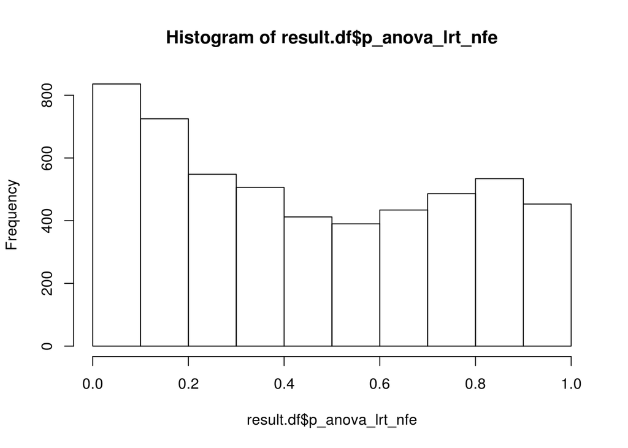

```r
hist(result.df$p_anova_lrt_nfe)
```

```r
hist(result.df$p_lrt_nfe)

sum(result.df$p_glm_nfe == 0)
```

```
## [1] 456
```

```r
sum(result.df$p_anova_lrt_nfe == 0)
```

```
## [1] 0
```

```r
sum(result.df$p_lrt_nfe == 0)
```

```
## [1] 0
```

[figure not shown]

```r
# Load function for nice qq-plots
source("f03_qqplot.R")
```

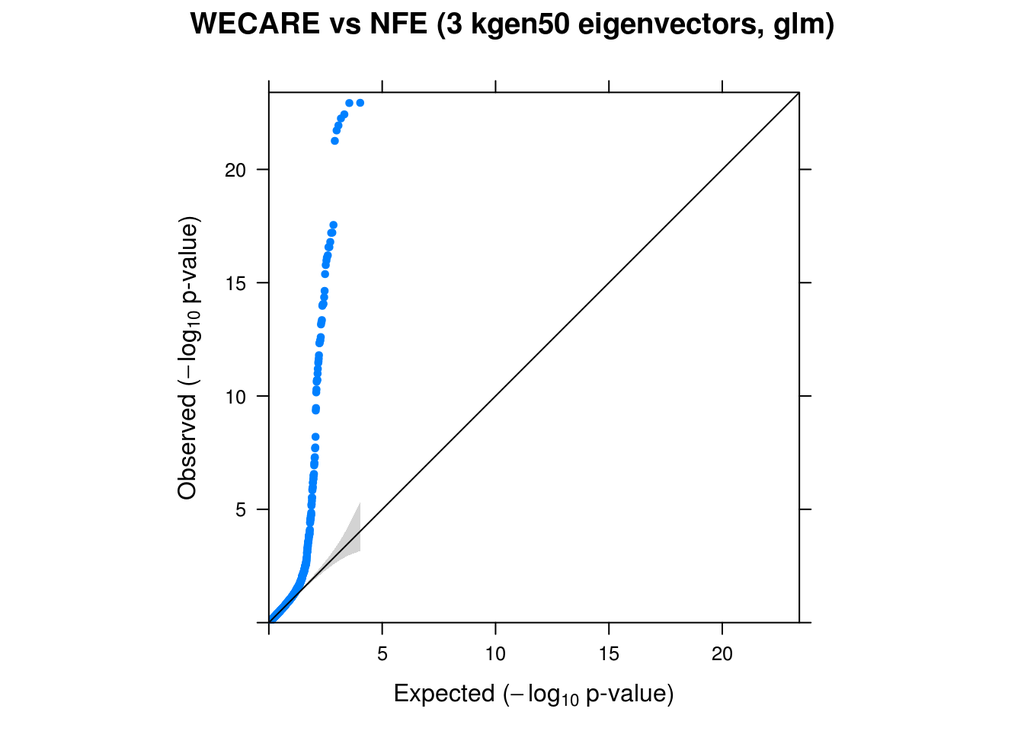

```r
qqunif.plot(result.df$p_glm_kgen50[!result.df$p_glm_kgen50 == 0], main="WECARE vs NFE (3 kgen50 eigenvectors, glm)")
```

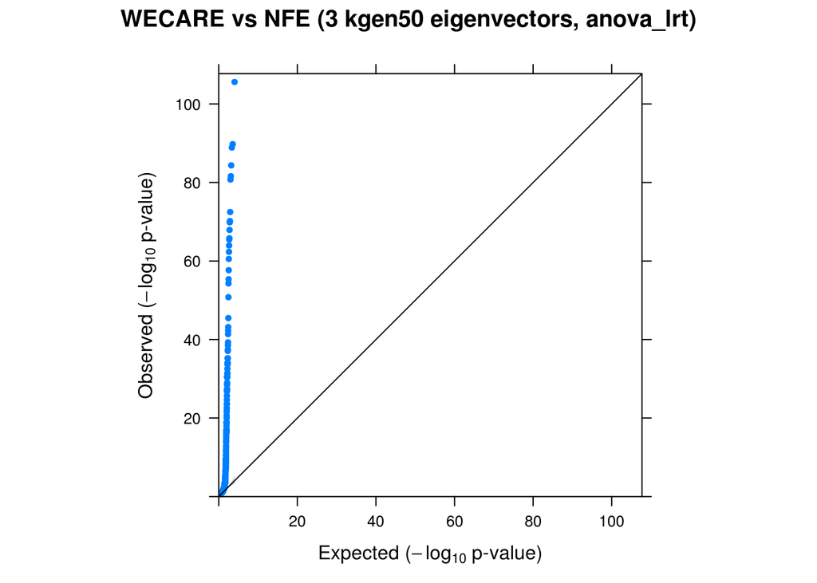

```r
qqunif.plot(result.df$p_anova_lrt_kgen50, main="WECARE vs NFE (3 kgen50 eigenvectors, anova_lrt)")
```

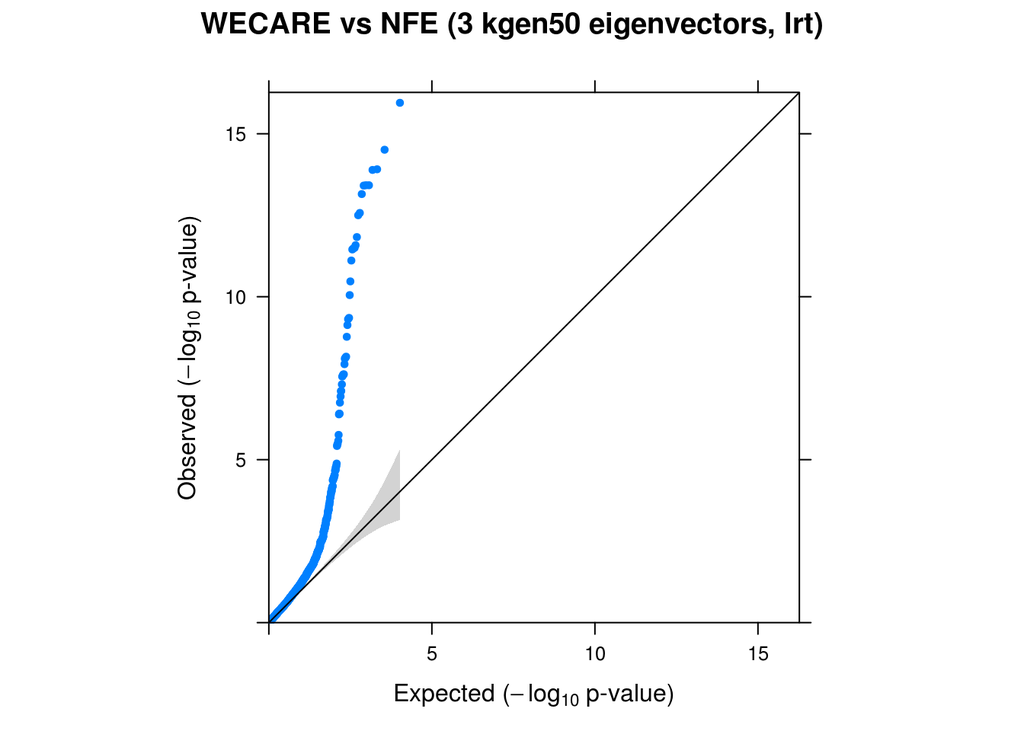

```r
qqunif.plot(result.df$p_lrt_kgen50[!result.df$p_lrt_kgen50==0], main="WECARE vs NFE (3 kgen50 eigenvectors, lrt)")
```

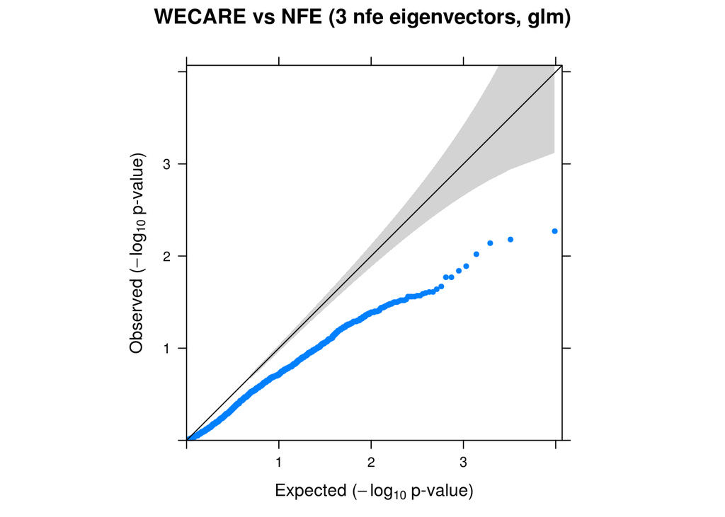

```r
qqunif.plot(result.df$p_glm_nfe[!result.df$p_glm_nfe == 0], main="WECARE vs NFE (3 nfe eigenvectors, glm)")
```

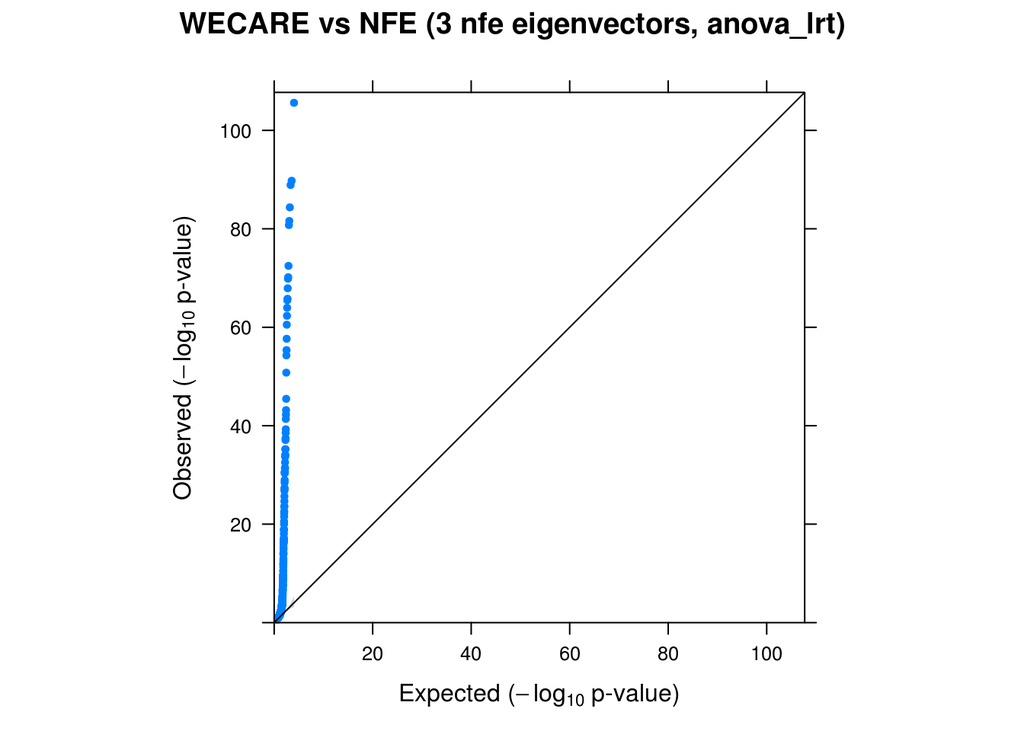

```r
qqunif.plot(result.df$p_anova_lrt_nfe, main="WECARE vs NFE (3 nfe eigenvectors, anova_lrt)")
```

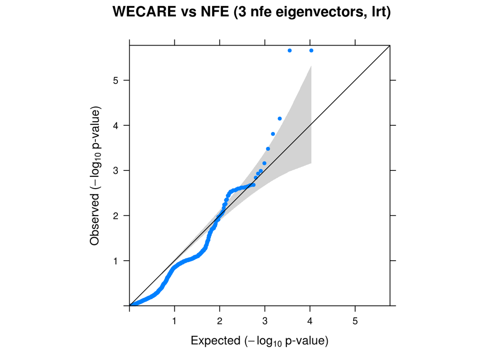

```r
qqunif.plot(result.df$p_lrt_nfe, main="WECARE vs NFE (3 nfe eigenvectors, lrt)")
```

```r
# Clean-up
rm(qqunif.plot, result.mx)
```

# data_summary

```r
dim(wecare_nfe_genotypes.mx)
```

```
## [1] 23523   676
```

```r
class(wecare_nfe_genotypes.mx)
```

```
## [1] "matrix"
```

```r
wecare_nfe_genotypes.mx[1:5,1:5]
```

```
##              HG00097 HG00099 HG00100 HG00102 HG00106
## Var000000026       0       0       0       0       0
## Var000000029       0       0       0       0       0
## Var000000031       0       0       0       0       0
## Var000000053       0       0       0       0       0
## Var000000064      NA       0       0       0       0
```

```r
dim(wecare_nfe_genes.df)
```

```
## [1] 10159     2
```

```r
class(wecare_nfe_genes.df)
```

```
## [1] "data.frame"
```

```r
wecare_nfe_genes.df[1:5,]
```

```
##         genes counts_per_gene
## NOC2L   NOC2L               4
## KLHL17 KLHL17               3
## AGRN     AGRN             147
## TTLL10 TTLL10               2
## ACAP3   ACAP3               2
```

```r
dim(wecare_nfe_kgen.df)
```

```
## [1] 23523     9
```

```r
colnames(wecare_nfe_kgen.df)
```

```
## [1] "SplitVarID"  "kgen.AC"     "kgen.AN"     "kgen.AF"     "kgen.AFR_AF"
## [6] "kgen.AMR_AF" "kgen.EAS_AF" "kgen.EUR_AF" "kgen.SAS_AF"
```

```r
wecare_nfe_kgen.df[1:5,1:5]
```

```
##                SplitVarID kgen.AC kgen.AN     kgen.AF kgen.AFR_AF
## Var000000026 Var000000026      NA      NA          NA          NA
## Var000000029 Var000000029       1    5008 0.000199681           0
## Var000000031 Var000000031       1    5008 0.000199681           0
## Var000000053 Var000000053      NA      NA          NA          NA
## Var000000064 Var000000064      NA      NA          NA          NA
```

```r
dim(wecare_nfe_exac.df)
```

```
## [1] 23523    48
```

```r
colnames(wecare_nfe_exac.df)
```

```
##  [1] "SplitVarID"              "exac_non_TCGA.AF"
##  [3] "exac_non_TCGA.AC"        "exac_non_TCGA.AN"
##  [5] "exac_non_TCGA.AC_FEMALE" "exac_non_TCGA.AN_FEMALE"
##  [7] "exac_non_TCGA.AC_MALE"   "exac_non_TCGA.AN_MALE"
##  [9] "exac_non_TCGA.AC_Adj"    "exac_non_TCGA.AN_Adj"
## [11] "exac_non_TCGA.AC_Hom"    "exac_non_TCGA.AC_Het"
## [13] "exac_non_TCGA.AC_Hemi"   "exac_non_TCGA.AC_AFR"
## [15] "exac_non_TCGA.AN_AFR"    "exac_non_TCGA.Hom_AFR"
## [17] "exac_non_TCGA.Het_AFR"   "exac_non_TCGA.Hemi_AFR"
## [19] "exac_non_TCGA.AC_AMR"    "exac_non_TCGA.AN_AMR"
## [21] "exac_non_TCGA.Hom_AMR"   "exac_non_TCGA.Het_AMR"
## [23] "exac_non_TCGA.Hemi_AMR"  "exac_non_TCGA.AC_EAS"
## [25] "exac_non_TCGA.AN_EAS"    "exac_non_TCGA.Hom_EAS"
## [27] "exac_non_TCGA.Het_EAS"   "exac_non_TCGA.Hemi_EAS"
## [29] "exac_non_TCGA.AC_FIN"    "exac_non_TCGA.AN_FIN"
## [31] "exac_non_TCGA.Hom_FIN"   "exac_non_TCGA.Het_FIN"
## [33] "exac_non_TCGA.Hemi_FIN"  "exac_non_TCGA.AC_NFE"
## [35] "exac_non_TCGA.AN_NFE"    "exac_non_TCGA.Hom_NFE"
## [37] "exac_non_TCGA.Het_NFE"   "exac_non_TCGA.Hemi_NFE"
## [39] "exac_non_TCGA.AC_SAS"    "exac_non_TCGA.AN_SAS"
## [41] "exac_non_TCGA.Hom_SAS"   "exac_non_TCGA.Het_SAS"
## [43] "exac_non_TCGA.Hemi_SAS"  "exac_non_TCGA.AC_OTH"
## [45] "exac_non_TCGA.AN_OTH"    "exac_non_TCGA.Hom_OTH"
## [47] "exac_non_TCGA.Het_OTH"   "exac_non_TCGA.Hemi_OTH"
```

```r
wecare_nfe_exac.df[1:5,1:5]
```

```
##                SplitVarID exac_non_TCGA.AF exac_non_TCGA.AC
## Var000000026 Var000000026               NA               NA
## Var000000029 Var000000029        1.506e-04               16
## Var000000031 Var000000031        2.354e-04               25
## Var000000053 Var000000053        1.883e-05                2
## Var000000064 Var000000064        9.416e-06                1
##              exac_non_TCGA.AN exac_non_TCGA.AC_FEMALE
## Var000000026               NA                      NA
## Var000000029           106210                       8
## Var000000031           106210                       4
## Var000000053           106210                       0
## Var000000064           106206                       0
```

```r
dim(wecare_nfe_variants.df)
```

```
## [1] 23523    50
```

```r
str(wecare_nfe_variants.df)
```

```
## 'data.frame':    23523 obs. of  50 variables:
##  $ SplitVarID        : Factor w/ 343824 levels "Var000000001",..: 26 29 31 53 64 65 167 191 227 237 ...
##  $ SYMBOL            : Factor w/ 19862 levels "A1BG","A1CF",..: 11149 11149 11149 8665 8665 8665 540 540 540 540 ...
##  $ TYPE              : Factor w/ 2 levels "INDEL","SNP": 2 2 2 2 2 2 2 2 2 2 ...
##  $ CHROM             : Factor w/ 25 levels "1","10","11",..: 1 1 1 1 1 1 1 1 1 1 ...
##  $ POS               : int  881871 883883 883946 897287 897792 897802 979748 982844 987173 989899 ...
##  $ REF               : Factor w/ 2142 levels "A","AAAAAAAAAAAAAAAAAAAAAAAG",..: 1044 1575 539 539 539 1575 1 1044 1575 539 ...
##  $ ALT               : Factor w/ 1297 levels "A","AAAAAAAAAAAAACT",..: 1 323 989 989 989 664 989 323 664 989 ...
##  $ ac_raw            : int  1 2 1 1 1 1 53 106 1 1 ...
##  $ af_raw            : num  0.000711 0.001555 0.000774 0.000711 0.000722 ...
##  $ an_raw            : int  1406 1286 1292 1406 1386 1390 1416 1388 1420 1414 ...
##  $ Consequence       : Factor w/ 78 levels "3_prime_UTR_variant",..: 66 28 28 28 66 28 28 24 28 28 ...
##  $ SIFT_call         : Factor w/ 4 levels "deleterious",..: NA 1 1 1 NA 1 1 NA 1 1 ...
##  $ SIFT_score        : num  NA 0 0.01 0.04 NA 0 0.01 NA 0 0.02 ...
##  $ PolyPhen_call     : Factor w/ 4 levels "benign","possibly_damaging",..: NA 3 3 3 NA 3 3 NA 3 3 ...
```

[output cut: 36 more lines]

```r
wecare_nfe_variants.df[1:5,1:5]
```

```
##                SplitVarID SYMBOL TYPE CHROM    POS
## Var000000026 Var000000026  NOC2L  SNP     1 881871
## Var000000029 Var000000029  NOC2L  SNP     1 883883
## Var000000031 Var000000031  NOC2L  SNP     1 883946
## Var000000053 Var000000053 KLHL17  SNP     1 897287
## Var000000064 Var000000064 KLHL17  SNP     1 897792
```

```r
dim(wecare_nfe_phenotypes.df)
```

```
## [1] 676  38
```

```r
str(wecare_nfe_phenotypes.df)
```

```
## 'data.frame':    676 obs. of  38 variables:
##  $ wes_id        : chr  "HG00097" "HG00099" "HG00100" "HG00102" ...
##  $ gwas_id       : chr  NA NA NA NA ...
##  $ merged_id     : chr  NA NA NA NA ...
##  $ filter        : chr  "pass" "pass" "pass" "pass" ...
##  $ cc            : num  -1 -1 -1 -1 -1 -1 -1 -1 -1 -1 ...
##  $ setno         : int  NA NA NA NA NA NA NA NA NA NA ...
##  $ registry      : chr  NA NA NA NA ...
##  $ family_history: int  NA NA NA NA NA NA NA NA NA NA ...
##  $ age_dx        : int  NA NA NA NA NA NA NA NA NA NA ...
##  $ age_ref       : num  NA NA NA NA NA NA NA NA NA NA ...
##  $ rstime        : num  NA NA NA NA NA NA NA NA NA NA ...
##  $ eig1_gwas     : num  NA NA NA NA NA NA NA NA NA NA ...
##  $ eig2_gwas     : num  NA NA NA NA NA NA NA NA NA NA ...
##  $ eig3_gwas     : num  NA NA NA NA NA NA NA NA NA NA ...
```

[output cut: 24 more lines]

```r
wecare_nfe_phenotypes.df[1:5,1:5]
```

```
##          wes_id gwas_id merged_id filter cc
## HG00097 HG00097    <NA>      <NA>   pass -1
## HG00099 HG00099    <NA>      <NA>   pass -1
## HG00100 HG00100    <NA>      <NA>   pass -1
## HG00102 HG00102    <NA>      <NA>   pass -1
## HG00106 HG00106    <NA>      <NA>   pass -1
```

```r
dim(result.df)
```

```
## [1] 5324    7
```

```r
str(result.df)
```

```
## 'data.frame':    5324 obs. of  7 variables:
##  $ gene              : chr  "TRBV10-1" "IGHJ5" "AC008271.1" "CKAP4" ...
##  $ p_glm_kgen50      : num  1.60e-17 1.93e-11 6.38e-09 1.35e-02 4.50e-01 ...
##  $ p_anova_lrt_kgen50: num  2.53e-106 1.76e-90 1.26e-15 6.01e-04 9.56e-01 ...
##  $ p_lrt_kgen50      : num  0.00 0.00 3.83e-14 1.44e-04 4.63e-01 ...
##  $ p_glm_nfe         : num  0.9971 0.9307 0.6228 0.216 0.0989 ...
##  $ p_anova_lrt_nfe   : num  2.53e-106 1.76e-90 1.26e-15 6.01e-04 9.56e-01 ...
##  $ p_lrt_nfe         : num  2.19e-06 2.19e-06 7.11e-05 1.55e-04 3.33e-04 ...
```

```r
result.df[1:5,1:5]
```

```
##            gene p_glm_kgen50 p_anova_lrt_kgen50 p_lrt_kgen50 p_glm_nfe
## 2205   TRBV10-1 1.603109e-17      2.533414e-106 0.000000e+00 0.9970810
## 3798      IGHJ5 1.930139e-11       1.757019e-90 0.000000e+00 0.9307295
## 578  AC008271.1 6.381022e-09       1.258693e-15 3.830269e-14 0.6227844
## 3455      CKAP4 1.350361e-02       6.013313e-04 1.440488e-04 0.2159650
## 782       SCN9A 4.502165e-01       9.561096e-01 4.632186e-01 0.0989442
```

```r
# Check consistency of rownames and colnames
sum(colnames(wecare_nfe_genotypes.mx) != rownames(wecare_nfe_phenotypes.df))
```

```
## [1] 0
```

```r
sum(rownames(wecare_nfe_genotypes.mx) != rownames(wecare_nfe_kgen.df))
```

```
## [1] 0
```

```r
sum(rownames(wecare_nfe_genotypes.mx) != rownames(wecare_nfe_exac.df))
```

```
## [1] 0
```

```r
sum(rownames(wecare_nfe_genotypes.mx) != rownames(wecare_nfe_variants.df))
```

```
## [1] 0
```

# save_data

```r
save.image(paste(interim_data_folder, "s08a_wecare_vs_nfe_glm_3ev_Mar2017.RData", sep="/"))
```

# final_section

```r
ls()
```

```
##  [1] "interim_data_folder"      "result.df"
##  [3] "results_folder"           "source_data_folder"
##  [5] "wecare_nfe_exac.df"       "wecare_nfe_genes.df"
##  [7] "wecare_nfe_genotypes.mx"  "wecare_nfe_kgen.df"
##  [9] "wecare_nfe_phenotypes.df" "wecare_nfe_variants.df"
```

```r
Sys.time()
```

```
## [1] "2017-04-01 19:22:57 BST"
```